# JMJPFU-Word Association

# JMJPFU

### 7-Feb-2017

This notebook is to demonstrate various methods of word association which will be used for text analytics. The process we will use is the following

1. Take a text for a particular sentiment, say anger
2. Find the most frequent words within the text
3. Find the most frequent associations for the given word for the text
4. Create templates based on these frequent words and word associations

### Reference Link : http://www.rdatamining.com/examples/text-mining

### Initial tasks : Loading the library files

```r
library(tm)
```

### Step1 : Pick the list of text which are relevant to the sentiment (Satisfaction)

The text will be picked from the list called hiltRev1 which was created on 6-Feb-2017

Let us pick the following texts , 11:30

```r
hiltSatisfaction <- hiltRev1[11:30]
```

### Step2 : Transforming the text into a dataframe for further analysis

```r
# Converting all the list elements to a dataframe
hiltSatisfacDf <- do.call("rbind",lapply(hiltSatisfaction,as.data.frame))
# Converting the factors to character
hiltSatisfacDf <- data.frame(lapply(hiltSatisfacDf,as.character),stringsAsFactors = FALSE)
# Providing a name to the text column
names(hiltSatisfacDf) <- "text"
```

### Step3 : Building a corpus of documents :

Requirement ; tm library

The next task is to build a corpus of documents for further analysis.

```r
hiltSatCorp <- Corpus(VectorSource(hiltSatisfacDf$text))
```

### Step4 : Transforming and cleaning the corpus:

The next task is to clean the corpus by removing punctuations, stopwords, numbers, changing to lower case , stemming etc

```r
# Converting to lowercase
hiltSatCorp <- tm_map(hiltSatCorp,tolower) # Another method for tolower is by applying content_transform. However it is seen to have problems in term document matrix later on
# hiltSatCorp <- tm_map(hiltSatCorp, PlainTextDocument)
# Remove punctuations
hiltSatCorp <- tm_map(hiltSatCorp,removePunctuation)
# Remove numbers
hiltSatCorp <- tm_map(hiltSatCorp,removeNumbers)
# Removing stopwords
hiltSatCorp <- tm_map(hiltSatCorp,removeWords,stopwords('english'))
inspect(hiltSatCorp[1:3])
```

```
<<VCorpus>>
Metadata:  corpus specific: 0, document level (indexed): 0
Content:  documents: 3

[[1]]
[1]  stayed   couple  months back   weekend    pleased   stay  pool  great   located   rooftop additionally  place  great eateries  bars  really enjoyed q bar    rooftop bar   great ambience especially  saturday nights  rooms  fantastic

[[2]]
[1] hotel     value   priceplus service  adequategood place   holiday getawaybreakfast buffet  worth  price  lot choicesall staffs   helpfulwell situated one   city

[[3]]
[1] one   best hotel stays ive   chennai  hilton chennai provided  great experience   staff professionalism  attention  detail  topnotch  hilton chennais location  guindy near  airport also makes  extremely convenient  accessibility    main shopping  tourist areas makes   great hotel
```

Next is to go for stemming of words which require the following packages

```r
library(SnowballC)
library(RWeka)
library(rJava)
library(RWekajars)
```

Proceeding with the stemming activities

```r
# Creating a dictionary so that words look same after stemming
dictSatis <- hiltSatCorp
# Doing the stemming
hiltSatCorp <- tm_map(hiltSatCorp,stemDocument)
# Stem Completions # This did not work
#hiltSatCorp <- tm_map(hiltSatCorp, PlainTextDocument)
#hiltSatCorp <- tm_map(hiltSatCorp,stemCompletion,dictionary=dictSatis) # This command had error in it . Will explore later
```

### Step 5 : Building the Term Document Matrix

The next task is to build the term document matrix and check for frequency of words

```r
hiltSatCorp <- tm_map(hiltSatCorp, PlainTextDocument)
inspect(hiltSatCorp[1:3])
```

```
<<VCorpus>>
Metadata:  corpus specific: 0, document level (indexed): 0
Content:  documents: 3

[[1]]
<<PlainTextDocument>>
Metadata:  7
Content:  chars: 234

[[2]]
<<PlainTextDocument>>
Metadata:  7
Content:  chars: 161

[[3]]
<<PlainTextDocument>>
Metadata:  7
Content:  chars: 280
```

```r
hiltSatCorp <- Corpus(VectorSource(hiltSatCorp))
hiltDtm <- TermDocumentMatrix(hiltSatCorp)
inspect(hiltDtm[1:10,1:20])
```

```
<<TermDocumentMatrix (terms: 10, documents: 20)>>
Non-/sparse entries: 14/186
Sparsity           : 93%
Maximal term length: 13
Weighting          : term frequency (tf)

               Docs
Terms           1 2 3 4 5 6 7 8 9 10 11 12 13 14 15 16 17 18 19 20
  absolutely    0 0 0 1 0 0 0 0 0  0  0  0  0  0  0  0  0  0  0  0
  accessibility 0 0 1 0 0 0 0 0 0  0  0  0  0  0  0  0  0  0  0  0
  accompnying   0 0 0 0 0 1 0 0 0  0  0  0  0  0  0  0  0  0  0  0
  additional    0 0 0 0 0 0 1 0 0  0  0  0  0  0  0  0  0  0  0  0
  additionally  1 0 0 0 0 0 0 0 0  0  0  0  0  0  0  0  0  0  0  0
  adequategood  0 1 0 0 0 0 0 0 0  0  0  0  0  0  0  0  0  0  0  0
  airport       0 0 1 0 0 0 0 0 0  1  0  0  0  0  0  0  0  0  1  0
  also          0 0 1 0 0 1 0 0 0  0  0  0  0  0  0  0  0  0  0  1
  alter         0 0 0 0 0 0 0 0 1  0  0  0  0  0  0  0  0  0  0  0
  although      0 0 0 0 0 1 0 0 0  0  0  0  0  0  0  0  0  0  0  0
```

```r
findAssocs(hiltDtm, 'hospitality', 0.30)
```

```
$hospitality
       trip    business accompnying    although    ambiance    arranged        came        come    daughter        days
       1.00        0.79        0.69        0.69        0.69        0.69        0.69        0.69        0.69        0.69
       done        ever       first       focus     getting      hilton        less        mind      needed     offered
       0.69        0.69        0.69        0.69        0.69        0.69        0.69        0.69        0.69        0.69
    options    services     staying      things   transfers    traveler     typical        word         got        help
       0.69        0.69        0.69        0.69        0.69        0.69        0.69        0.69        0.44        0.44
     hotels     perfect    pleasure    provided       thing       views       visit        warm       weeks        wife
       0.44        0.44        0.44        0.44        0.44        0.44        0.44        0.44        0.44        0.44
  wonderful      stayed        also  facilities        food      indian     special
       0.44        0.42        0.33        0.33        0.33        0.33        0.33
```

# JMJPFU

## 8-Feb-2017

1. Let us now create a wordcloud and look at the most frequent words.
2. Also will convert the term document into a matrix format

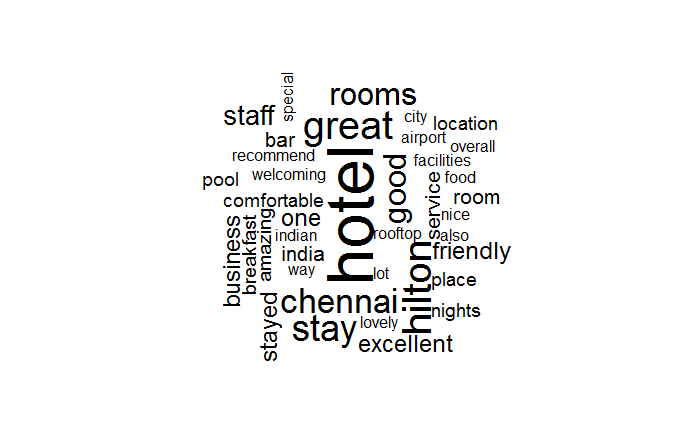

|  | word | freq |
| --- | --- | --- |
| hotel | hotel | 21 |
| great | great | 12 |
| hilton | hilton | 12 |
| stay | stay | 11 |
| chennai | chennai | 10 |
| good | good | 9 |
| rooms | rooms | 9 |
| staff | staff | 7 |
| business | business | 6 |
| excellent | excellent | 6 |

[output cut: 328 more lines]

Let us now find some association with some key words

```r
findAssocs(hiltDtm, 'food',0.30)
```

```
$food
   additional      ambiance      arranged      beverage          cake        cherry      complete  consistently
         0.55          0.55          0.55          0.55          0.55          0.55          0.55          0.55
         days        decent          done      exceeded        experi          feel         focus         found
         0.55          0.55          0.55          0.55          0.55          0.55          0.55          0.55
      getting           hom international       missing        needed       offered       options     selection
         0.55          0.55          0.55          0.55          0.55          0.55          0.55          0.55
     services       staying        things     transfers      traveler       typical        warmth       amazing
         0.55          0.55          0.55          0.55          0.55          0.55          0.55          0.49
     business          good        hilton           bar       choices         close    definitely   hospitality
         0.41          0.38          0.34          0.33          0.33          0.33          0.33          0.33
       making       perfect      pleasure      provided   restaurants           say       service      situated
         0.33          0.33          0.33          0.33          0.33          0.33          0.33          0.33
    standards        thanks         thing          trip         views          well
         0.33          0.33          0.33          0.33          0.33          0.33
```

```r
hiltSatisfacDf[20,1]
```

```
[1] "Excellent stay. Friendly professional warm and welcoming. Overall: everything perfect. Breakfast very good (lot to choose from: Indian, Asian, Continental, Fruits, Fish) Room service: very good. Nice towel animals. Dinner also very good. Everybody very friendly. I can recommend this hotel."
```

So from a modelling perspective we can use many of the methods for extracting features from the data. Here are some of the suggestions

1. Word associations can be used for template creation. Take each of the variables of a hotel like Room, Restaurant, Pickup, cleanliness etc and then find their associations. Classify the associations as “anger”,“satisfied” etc for the associations. So when a new text is received, analyse them against the template and then enter them as a feature.
2. Second thing which can be explored is the vector space models. We can create each template as Vector Space models and look for similarity with these VSMs for new data and the similarity can be made into a feature.

A link to try out

https://www.kaggle.com/lrargerich/crowdflower-search-relevance/r-vector-space-model/output

A good document on Paradigmatic and syntigmatic associations

http://www.aclweb.org/anthology/C02-1007